## How-to

#### Exponential Smoothing

For an explanation of the ideas of exponential smoothing, I can’t recommend more the second chapter (free) of [Forecasting with Exponential Smoothing: A State Space Approach](http://www.exponentialsmoothing.net/toc) by Rob J. Hyndman, Anne B. Koehler, J. Keith Ord, and Ralph D. Snyder

#### Example

We will now illustrate a particular case of estimating an exponential smoothing problem, taken from the previously mentioned book.

Our data will be the inbuilt dataset in *R*, *USAccDeaths*, a dataset consisting of Accidental Deaths in the US 1973-1978. We will fit an “optimal” exponential smoothing model by using an automatic inbuilt algorithm in the *ets* *R* package and forecast 12 months of data.

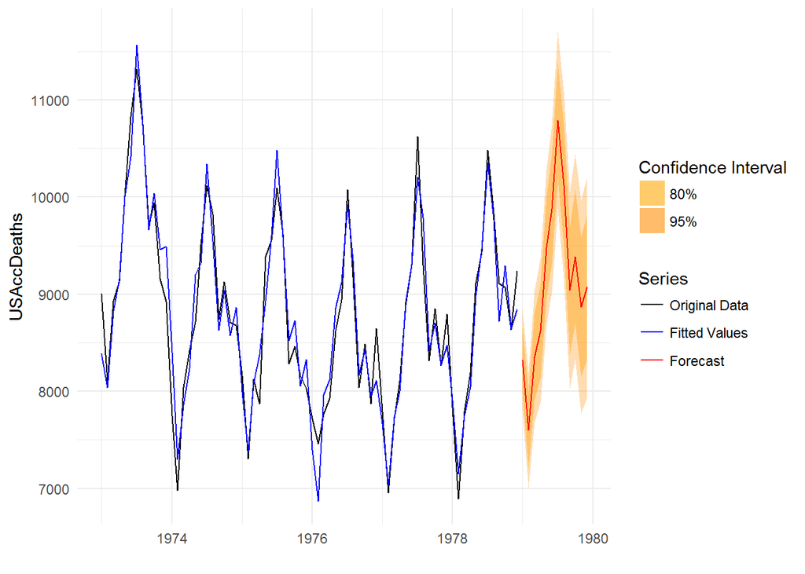

```
##
## Forecast method: ETS(A,N,A)
##
## Model Information:
## ETS(A,N,A)
##
## Call:
##  ets(y = USAccDeaths)
##
##   Smoothing parameters:
##     alpha = 0.5891
##     gamma = 1e-04
##
##   Initial states:
##     l = 9196.9696
##     s=-50.3296 -259.3484 256.8254 -87.421 994.235 1659.364
##            752.2699 349.7909 -505.1988 -776.3242 -1524.744 -809.1198
##
##   sigma:  264.7529
##
##      AIC     AICc      BIC
## 1141.267 1149.838 1175.417
##
## Error measures:
##                     ME     RMSE      MAE         MPE     MAPE      MASE
## Training set -1.603301 264.7529 204.2708 -0.07230784 2.352901 0.4671717
##                     ACF1
## Training set -0.00392235
##
## Forecasts:
##          Point Forecast     Lo 80     Hi 80    Lo 95     Hi 95
## Jan 1979       8319.902  7980.608  8659.197 7800.996  8838.809
## Feb 1979       7604.221  7210.437  7998.005 7001.981  8206.461
## Mar 1979       8352.662  7911.063  8794.262 7677.294  9028.031
## Apr 1979       8623.743  8139.021  9108.465 7882.425  9365.061
## May 1979       9478.746  8954.437 10003.055 8676.884 10280.608
## Jun 1979       9881.276  9320.165 10442.387 9023.132 10739.420
## Jul 1979      10788.320 10192.677 11383.962 9877.363 11699.276
## Aug 1979      10123.176  9494.897 10751.455 9162.306 11084.046
## Sep 1979       9041.557  8382.255  9700.860 8033.242 10049.873
## Oct 1979       9385.766  8696.836 10074.696 8332.139 10439.394
## Nov 1979       8869.606  8152.271  9586.941 7772.537  9966.675
## Dec 1979       9078.661  8333.995  9823.328 7939.793 10217.530
```

In order to obtain this plot set:

- Error Type: Aditive
- Trend Type: None
- Season Type: Aditive

Or, if you’re feeling a little bit lazy, just click the “Fit and Forecast” button as the default values and data are set to deliver our example plot.

#### Prohibited combinations

Let the first element stand for the “Error Type” specification, the second element for the “Trend type” specification and the third element for the “Season Type” specification. Let *N* denote “None”, *A* “Aditive”, and *M* “Multiplicative”. The following are non allowed ETS model specifications:

- ANM
- AMN
- AMA
- AAM
- AMM
- MMA